# Question

Let’s consider an alternative way to multiply 23 and 56.

First, let’s break each number into its tens and ones.

$$23 ~~=~~ 20+3$$
$$56 ~~=~~ 50+6$$

Now, find all 4 indicated products. Also, find the totals.

| * | $20$ | $3$ | **total** |
| --- | --- | --- | --- |
| $50$ | ##ANSWER1## | ##ANSWER2## | ##ANSWER5## |
| $6$ | ##ANSWER3## | ##ANSWER4## | ##ANSWER6## |
| **total** | ##ANSWER7## | ##ANSWER8## | ##ANSWER9## |

## Answerlist

- 10
- 100
- 1000
- 10000
- 15
- 150
- 1500
- 15000
- 12
- 120
- 1200
- 12000
- 18
- 180
- 1800
- 18000
- 138
- 168
- 1120
- 1150
- 1288
- 138
- 168
- 1120
- 1150
- 1288
- 138
- 168
- 1120
- 1150
- 1288
- 138
- 168
- 1120
- 1150
- 1288
- 138
- 168
- 1120
- 1150
- 1288

# Solution

$$23\cdot 56 = 1288$$

| * | $20$ | $3$ | **total** |
| --- | --- | --- | --- |
| $50$ | 1000 | 150 | 1150 |
| $6$ | 120 | 18 | 138 |
| **total** | 1120 | 168 | 1288 |

At some point I learned about the [multiplication by lines](https://www.mathnstuff.com/math/spoken/here/2class/60/bylines.htm) method. You’ll notice there are 2 lines above 3 lines, both with positive slope. There are also 5 lines above 6 lines, both with negative slope. The number of intersections in the four corners are found with multiplication: $2\cdot5=10$ and $3\cdot5=15$ and $2\cdot6=12$ and $3\cdot6=18$.

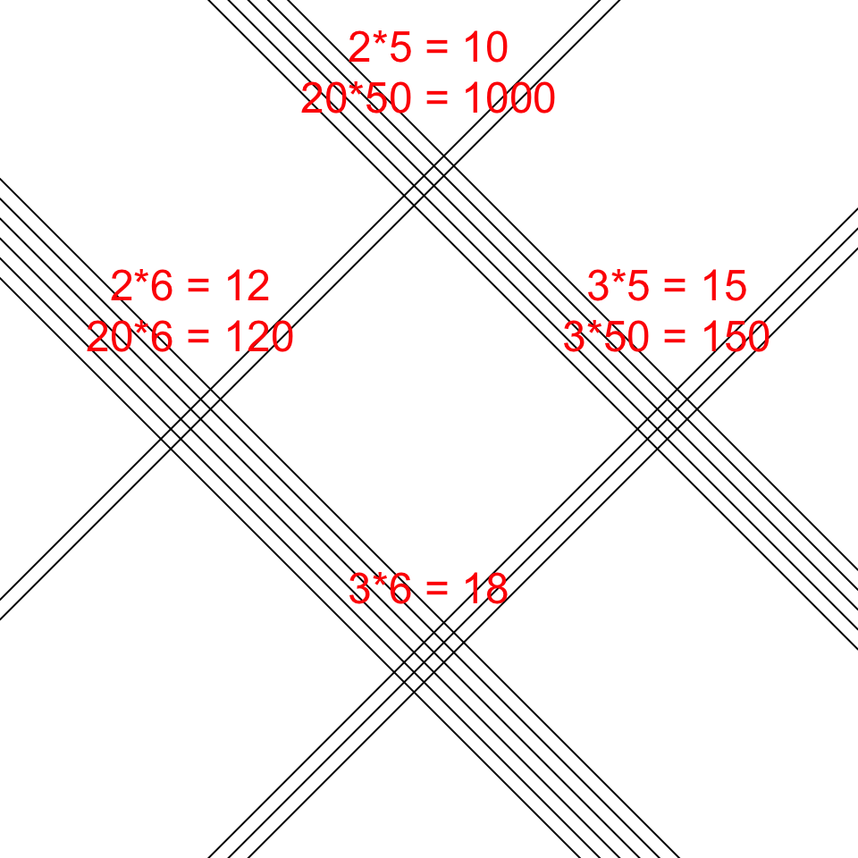

$$1000 + 150 + 120 + 18 ~~=~~
1288$$

# Meta-information

extype: cloze exclozetype: schoice|schoice|schoice|schoice|schoice|schoice|schoice|schoice|schoice exsolution: 0010|0100|0100|1000|00010|10000|00100|01000|00001 exname: multiply_2digits